# Project: Investigate a Dataset - [No Appointment Show]

- Introduction
- Data Wrangling
- Exploratory Data Analysis
- Conclusions

## Introduction

### Dataset Description

This dataset collects information from 100k medical appointments in Brazil and is focused on the question of whether or not patients show up for their appointment. A number of characteristics about the patient are included in each row.

● ‘ScheduledDay’ tells us on what day the patient set up their appointment.

● ‘Neighborhood’ indicates the location of the hospital.

● ‘Scholarship’ indicates whether or not the patient is enrolled in Brasilian welfare program Bolsa Família.

● Be careful about the encoding of the last column: it says ‘No’ if the patient showed up to their appointment, and ‘Yes’ if they did not show up.

### Question(s) for Analysis

1) What is the overall rate?

2) What is the Show rate?

3) Does Gender rate and Does Gender Affect of attend?

4) Does Age Affect of attend?

5) Does Neighbourhood Affect of attend?

6) Does Scholarship Affect of attend?

7) Does SMS Affect of attend?

8) Does Handcap Affect of attend?

9) Does Alcoholism Affect of attend?

```python
# Use this cell to set up import statements for all of the packages that you
#   plan to use.

# Remember to include a 'magic word' so that your visualizations are plotted
#   inline with the notebook. See this page for more:
#   http://ipython.readthedocs.io/en/stable/interactive/magics.html
import time
import numpy as np
import pandas as pd
import matplotlib.pyplot as plt
import seaborn as sns

% matplotlib inline
```

```python
# Upgrade pandas to use dataframe.explode() function.
!pip install --upgrade pandas==0.25.0
```

## Data Wrangling

In this section of the report, will load in the data, check for cleanliness, and then trim and clean dataset for analysis.

```python
#Read the dataset.
df = pd.read_csv('noshowappointments-kagglev2-may-2016.csv')
df.head()
```

|  | PatientId | AppointmentID | Gender | ScheduledDay | AppointmentDay | Age | Neighbourhood | Scholarship | Hipertension | Diabetes | Alcoholism | Handcap | SMS_received | No-show |
| --- | --- | --- | --- | --- | --- | --- | --- | --- | --- | --- | --- | --- | --- | --- |
| 0 | 2.987250e+13 | 5642903 | F | 2016-04-29T18:38:08Z | 2016-04-29T00:00:00Z | 62 | JARDIM DA PENHA | 0 | 1 | 0 | 0 | 0 | 0 | No |
| 1 | 5.589978e+14 | 5642503 | M | 2016-04-29T16:08:27Z | 2016-04-29T00:00:00Z | 56 | JARDIM DA PENHA | 0 | 0 | 0 | 0 | 0 | 0 | No |
| 2 | 4.262962e+12 | 5642549 | F | 2016-04-29T16:19:04Z | 2016-04-29T00:00:00Z | 62 | MATA DA PRAIA | 0 | 0 | 0 | 0 | 0 | 0 | No |
| 3 | 8.679512e+11 | 5642828 | F | 2016-04-29T17:29:31Z | 2016-04-29T00:00:00Z | 8 | PONTAL DE CAMBURI | 0 | 0 | 0 | 0 | 0 | 0 | No |
| 4 | 8.841186e+12 | 5642494 | F | 2016-04-29T16:07:23Z | 2016-04-29T00:00:00Z | 56 | JARDIM DA PENHA | 0 | 1 | 1 | 0 | 0 | 0 | No |

```python
# the shape of data.
df.shape
```

```
(110527, 14)
```

```python
# discover information about the data and check for any missing values in the data.
df.info()
```

```
<class 'pandas.core.frame.DataFrame'>
RangeIndex: 110527 entries, 0 to 110526
Data columns (total 14 columns):
PatientId         110527 non-null float64
AppointmentID     110527 non-null int64
Gender            110527 non-null object
ScheduledDay      110527 non-null object
AppointmentDay    110527 non-null object
Age               110527 non-null int64
Neighbourhood     110527 non-null object
Scholarship       110527 non-null int64
Hipertension      110527 non-null int64
Diabetes          110527 non-null int64
Alcoholism        110527 non-null int64
Handcap           110527 non-null int64
SMS_received      110527 non-null int64
No-show           110527 non-null object
dtypes: float64(1), int64(8), object(5)
memory usage: 11.8+ MB
```

```python
# Describe the data.
df.describe()
```

|  | PatientId | AppointmentID | Age | Scholarship | Hipertension | Diabetes | Alcoholism | Handcap | SMS_received |
| --- | --- | --- | --- | --- | --- | --- | --- | --- | --- |
| count | 1.105270e+05 | 1.105270e+05 | 110527.000000 | 110527.000000 | 110527.000000 | 110527.000000 | 110527.000000 | 110527.000000 | 110527.000000 |
| mean | 1.474963e+14 | 5.675305e+06 | 37.088874 | 0.098266 | 0.197246 | 0.071865 | 0.030400 | 0.022248 | 0.321026 |
| std | 2.560949e+14 | 7.129575e+04 | 23.110205 | 0.297675 | 0.397921 | 0.258265 | 0.171686 | 0.161543 | 0.466873 |
| min | 3.921784e+04 | 5.030230e+06 | -1.000000 | 0.000000 | 0.000000 | 0.000000 | 0.000000 | 0.000000 | 0.000000 |
| 25% | 4.172614e+12 | 5.640286e+06 | 18.000000 | 0.000000 | 0.000000 | 0.000000 | 0.000000 | 0.000000 | 0.000000 |
| 50% | 3.173184e+13 | 5.680573e+06 | 37.000000 | 0.000000 | 0.000000 | 0.000000 | 0.000000 | 0.000000 | 0.000000 |
| 75% | 9.439172e+13 | 5.725524e+06 | 55.000000 | 0.000000 | 0.000000 | 0.000000 | 0.000000 | 0.000000 | 1.000000 |
| max | 9.999816e+14 | 5.790484e+06 | 115.000000 | 1.000000 | 1.000000 | 1.000000 | 1.000000 | 4.000000 | 1.000000 |

```python
# check for duplicates in the data.
df.duplicated().sum()
```

```
0
```

```python
# check for if there are age equal and below zero.
df[df['Age'] <=0 ]
```

|  | PatientId | AppointmentID | Gender | ScheduledDay | AppointmentDay | Age | Neighbourhood | Scholarship | Hipertension | Diabetes | Alcoholism | Handcap | SMS_received | No-show |
| --- | --- | --- | --- | --- | --- | --- | --- | --- | --- | --- | --- | --- | --- | --- |
| 59 | 7.184428e+13 | 5638545 | F | 2016-04-29T08:08:43Z | 2016-04-29T00:00:00Z | 0 | CONQUISTA | 0 | 0 | 0 | 0 | 0 | 0 | No |
| 63 | 2.366233e+14 | 5628286 | M | 2016-04-27T10:46:12Z | 2016-04-29T00:00:00Z | 0 | SÃO BENEDITO | 0 | 0 | 0 | 0 | 0 | 0 | No |
| 64 | 1.885174e+14 | 5616082 | M | 2016-04-25T13:28:21Z | 2016-04-29T00:00:00Z | 0 | ILHA DAS CAIEIRAS | 0 | 0 | 0 | 0 | 0 | 1 | No |
| 65 | 2.718818e+14 | 5628321 | M | 2016-04-27T10:48:50Z | 2016-04-29T00:00:00Z | 0 | CONQUISTA | 0 | 0 | 0 | 0 | 0 | 0 | No |
| 67 | 8.647128e+13 | 5639264 | F | 2016-04-29T08:53:02Z | 2016-04-29T00:00:00Z | 0 | NOVA PALESTINA | 0 | 0 | 0 | 0 | 0 | 0 | No |
| 89 | 4.314932e+14 | 5640380 | M | 2016-04-29T10:37:02Z | 2016-04-29T00:00:00Z | 0 | MONTE BELO | 0 | 0 | 0 | 0 | 0 | 0 | No |
| 101 | 6.822847e+13 | 5642813 | M | 2016-04-29T17:24:19Z | 2016-04-29T00:00:00Z | 0 | BONFIM | 0 | 0 | 0 | 0 | 0 | 0 | No |
| 104 | 3.326985e+12 | 5632495 | F | 2016-04-28T08:04:48Z | 2016-04-29T00:00:00Z | 0 | SANTO ANTÔNIO | 0 | 0 | 0 | 0 | 0 | 0 | Yes |
| 132 | 8.468587e+14 | 5560742 | M | 2016-04-08T09:29:23Z | 2016-04-29T00:00:00Z | 0 | PRAIA DO SUÁ | 0 | 0 | 0 | 0 | 0 | 1 | Yes |
| 150 | 5.392419e+10 | 5641476 | M | 2016-04-29T13:43:34Z | 2016-04-29T00:00:00Z | 0 | ITARARÉ | 0 | 0 | 0 | 0 | 0 | 0 | No |
| 188 | 1.883366e+14 | 5640933 | M | 2016-04-29T11:44:49Z | 2016-04-29T00:00:00Z | 0 | NOVA PALESTINA | 0 | 0 | 0 | 0 | 0 | 0 | No |
| 192 | 1.165338e+12 | 5640561 | M | 2016-04-29T10:57:14Z | 2016-04-29T00:00:00Z | 0 | CONQUISTA | 0 | 0 | 0 | 0 | 0 | 0 | No |
| 193 | 2.379698e+11 | 5532452 | F | 2016-03-31T11:14:57Z | 2016-04-29T00:00:00Z | 0 | NOVA PALESTINA | 0 | 0 | 0 | 0 | 0 | 1 | No |
| 194 | 4.442538e+11 | 5539566 | M | 2016-04-01T15:17:10Z | 2016-04-29T00:00:00Z | 0 | REDENÇÃO | 0 | 0 | 0 | 0 | 0 | 0 | No |
| 250 | 2.942723e+14 | 5640181 | M | 2016-04-29T10:13:35Z | 2016-04-29T00:00:00Z | 0 | CARATOÍRA | 0 | 0 | 0 | 0 | 0 | 0 | Yes |
| 256 | 8.599713e+10 | 5629906 | F | 2016-04-27T14:19:02Z | 2016-04-29T00:00:00Z | 0 | ARIOVALDO FAVALESSA | 0 | 0 | 0 | 0 | 0 | 0 | Yes |
| 266 | 1.198173e+13 | 5639237 | M | 2016-04-29T08:50:09Z | 2016-04-29T00:00:00Z | 0 | MARIA ORTIZ | 0 | 0 | 0 | 0 | 0 | 0 | No |
| 292 | 4.645238e+13 | 5642766 | F | 2016-04-29T17:06:22Z | 2016-04-29T00:00:00Z | 0 | GURIGICA | 0 | 0 | 0 | 0 | 0 | 0 | No |
| 305 | 9.794819e+11 | 5638226 | F | 2016-04-29T07:49:54Z | 2016-04-29T00:00:00Z | 0 | JOANA D´ARC | 0 | 0 | 0 | 0 | 0 | 0 | No |
| 306 | 2.648746e+11 | 5638370 | M | 2016-04-29T07:58:15Z | 2016-04-29T00:00:00Z | 0 | SANTA MARTHA | 0 | 0 | 0 | 0 | 0 | 0 | No |
| 310 | 3.732371e+14 | 5639056 | M | 2016-04-29T08:40:58Z | 2016-04-29T00:00:00Z | 0 | SANTA MARTHA | 0 | 0 | 0 | 0 | 0 | 0 | No |
| 358 | 7.349270e+14 | 5531831 | F | 2016-03-31T10:07:18Z | 2016-04-29T00:00:00Z | 0 | CONSOLAÇÃO | 0 | 0 | 0 | 0 | 0 | 0 | Yes |
| 359 | 7.975283e+11 | 5551583 | M | 2016-04-06T14:20:30Z | 2016-04-29T00:00:00Z | 0 | CONSOLAÇÃO | 0 | 0 | 0 | 0 | 0 | 0 | No |
| 366 | 3.499167e+14 | 5531933 | F | 2016-03-31T10:14:54Z | 2016-04-29T00:00:00Z | 0 | CONSOLAÇÃO | 0 | 0 | 0 | 0 | 0 | 1 | Yes |
| 377 | 9.123627e+11 | 5522585 | M | 2016-03-29T14:39:32Z | 2016-04-29T00:00:00Z | 0 | DA PENHA | 0 | 0 | 0 | 0 | 0 | 1 | No |
| 434 | 9.625417e+14 | 5533985 | F | 2016-03-31T15:01:12Z | 2016-04-29T00:00:00Z | 0 | MORADA DE CAMBURI | 0 | 0 | 0 | 0 | 0 | 1 | Yes |
| 524 | 5.815365e+13 | 5488633 | M | 2016-03-18T10:35:28Z | 2016-04-29T00:00:00Z | 0 | ITARARÉ | 0 | 0 | 0 | 0 | 0 | 1 | No |
| 525 | 4.239228e+13 | 5537936 | F | 2016-04-01T10:53:45Z | 2016-04-29T00:00:00Z | 0 | ITARARÉ | 0 | 0 | 0 | 0 | 0 | 1 | Yes |
| 526 | 8.574376e+12 | 5639659 | M | 2016-04-29T09:22:07Z | 2016-04-29T00:00:00Z | 0 | ITARARÉ | 0 | 0 | 0 | 0 | 0 | 0 | No |
| 565 | 5.569896e+14 | 5591488 | F | 2016-04-15T17:39:38Z | 2016-04-29T00:00:00Z | 0 | SANTA LUÍZA | 0 | 0 | 0 | 0 | 0 | 1 | No |
| ... | ... | ... | ... | ... | ... | ... | ... | ... | ... | ... | ... | ... | ... | ... |
| 109629 | 3.689222e+13 | 5660428 | F | 2016-05-04T16:30:06Z | 2016-06-01T00:00:00Z | 0 | ROMÃO | 0 | 0 | 0 | 0 | 0 | 0 | Yes |
| 109633 | 3.689222e+13 | 5660427 | F | 2016-05-04T16:30:06Z | 2016-06-01T00:00:00Z | 0 | ROMÃO | 0 | 0 | 0 | 0 | 0 | 1 | Yes |
| 109646 | 5.941811e+13 | 5659194 | M | 2016-05-04T13:21:32Z | 2016-06-01T00:00:00Z | 0 | FORTE SÃO JOÃO | 0 | 0 | 0 | 0 | 0 | 0 | No |
| 109647 | 5.635258e+13 | 5691391 | M | 2016-05-12T12:35:04Z | 2016-06-08T00:00:00Z | 0 | FORTE SÃO JOÃO | 0 | 0 | 0 | 0 | 0 | 0 | Yes |
| 109649 | 5.941811e+13 | 5659193 | M | 2016-05-04T13:21:32Z | 2016-06-01T00:00:00Z | 0 | FORTE SÃO JOÃO | 0 | 0 | 0 | 0 | 0 | 0 | No |
| 109650 | 5.635258e+13 | 5691390 | M | 2016-05-12T12:35:04Z | 2016-06-08T00:00:00Z | 0 | FORTE SÃO JOÃO | 0 | 0 | 0 | 0 | 0 | 0 | Yes |
| 109830 | 6.931429e+11 | 5739239 | F | 2016-05-25T13:07:38Z | 2016-06-02T00:00:00Z | 0 | SÃO BENEDITO | 0 | 0 | 0 | 0 | 0 | 0 | Yes |
| 109847 | 9.174483e+11 | 5685977 | M | 2016-05-11T11:33:48Z | 2016-06-02T00:00:00Z | 0 | NOVA PALESTINA | 0 | 0 | 0 | 0 | 0 | 1 | Yes |
| 109848 | 5.853540e+12 | 5707361 | M | 2016-05-17T09:32:32Z | 2016-06-02T00:00:00Z | 0 | RESISTÊNCIA | 0 | 0 | 0 | 0 | 0 | 0 | No |
| 109852 | 1.663316e+13 | 5731578 | F | 2016-05-24T10:14:26Z | 2016-06-02T00:00:00Z | 0 | RESISTÊNCIA | 0 | 0 | 0 | 0 | 0 | 0 | No |
| 110231 | 1.731548e+14 | 5634706 | M | 2016-04-28T11:32:00Z | 2016-06-01T00:00:00Z | 0 | RESISTÊNCIA | 0 | 0 | 0 | 0 | 0 | 0 | No |
| 110235 | 3.279373e+14 | 5634274 | M | 2016-04-28T10:40:49Z | 2016-06-01T00:00:00Z | 0 | RESISTÊNCIA | 0 | 0 | 0 | 0 | 0 | 0 | Yes |
| 110236 | 1.174717e+13 | 5669996 | M | 2016-05-06T12:31:22Z | 2016-06-08T00:00:00Z | 0 | RESISTÊNCIA | 0 | 0 | 0 | 0 | 0 | 1 | No |
| 110299 | 5.944513e+10 | 5746323 | F | 2016-05-30T13:47:40Z | 2016-06-07T00:00:00Z | 0 | RESISTÊNCIA | 0 | 0 | 0 | 0 | 0 | 1 | Yes |
| 110313 | 8.535734e+12 | 5600209 | F | 2016-04-19T10:09:05Z | 2016-06-06T00:00:00Z | 0 | RESISTÊNCIA | 0 | 0 | 0 | 0 | 0 | 1 | No |
| 110319 | 4.524190e+11 | 5640301 | F | 2016-04-29T10:28:16Z | 2016-06-06T00:00:00Z | 0 | RESISTÊNCIA | 0 | 0 | 0 | 0 | 0 | 1 | No |
| 110320 | 3.459268e+13 | 5675103 | M | 2016-05-09T13:02:20Z | 2016-06-06T00:00:00Z | 0 | RESISTÊNCIA | 0 | 0 | 0 | 0 | 0 | 1 | No |
| 110321 | 1.388630e+11 | 5338643 | M | 2016-02-11T16:14:32Z | 2016-06-01T00:00:00Z | 0 | RESISTÊNCIA | 0 | 0 | 0 | 0 | 0 | 1 | No |
| 110331 | 2.739486e+13 | 5392089 | F | 2016-02-24T15:33:08Z | 2016-06-01T00:00:00Z | 0 | RESISTÊNCIA | 0 | 0 | 0 | 0 | 0 | 1 | Yes |
| 110334 | 1.174717e+13 | 5756343 | M | 2016-06-01T08:12:55Z | 2016-06-01T00:00:00Z | 0 | RESISTÊNCIA | 0 | 0 | 0 | 0 | 0 | 0 | No |
| 110335 | 3.747953e+11 | 5338761 | M | 2016-02-11T16:39:26Z | 2016-06-01T00:00:00Z | 0 | RESISTÊNCIA | 0 | 0 | 0 | 0 | 0 | 1 | No |
| 110339 | 3.731746e+12 | 5584042 | M | 2016-04-14T13:01:21Z | 2016-06-01T00:00:00Z | 0 | RESISTÊNCIA | 0 | 0 | 0 | 0 | 0 | 1 | Yes |
| 110341 | 4.696832e+12 | 5713894 | M | 2016-05-18T10:55:00Z | 2016-06-01T00:00:00Z | 0 | RESISTÊNCIA | 0 | 0 | 0 | 0 | 0 | 1 | No |
| 110342 | 3.147163e+11 | 5776749 | M | 2016-06-06T11:48:00Z | 2016-06-08T00:00:00Z | 0 | RESISTÊNCIA | 0 | 0 | 0 | 0 | 0 | 0 | No |
| 110343 | 1.759439e+12 | 5690822 | F | 2016-05-12T10:43:50Z | 2016-06-01T00:00:00Z | 0 | RESISTÊNCIA | 0 | 0 | 0 | 0 | 0 | 1 | No |
| 110345 | 1.473952e+14 | 5702537 | F | 2016-05-16T12:30:58Z | 2016-06-01T00:00:00Z | 0 | RESISTÊNCIA | 0 | 0 | 0 | 0 | 0 | 0 | No |
| 110346 | 5.577525e+12 | 5777724 | M | 2016-06-06T14:22:34Z | 2016-06-08T00:00:00Z | 0 | RESISTÊNCIA | 0 | 0 | 0 | 0 | 0 | 0 | No |
| 110454 | 6.142460e+11 | 5772400 | F | 2016-06-03T15:18:44Z | 2016-06-03T00:00:00Z | 0 | RESISTÊNCIA | 0 | 0 | 0 | 0 | 0 | 0 | No |
| 110460 | 4.321846e+13 | 5769545 | F | 2016-06-03T08:56:51Z | 2016-06-03T00:00:00Z | 0 | RESISTÊNCIA | 0 | 0 | 0 | 0 | 0 | 0 | No |
| 110507 | 4.769462e+14 | 5786918 | F | 2016-06-08T09:04:18Z | 2016-06-08T00:00:00Z | 0 | MARIA ORTIZ | 0 | 0 | 0 | 0 | 0 | 0 | No |

3540 rows × 14 columns

### Data Cleaning

```python
# drop rows that contains age <= 0 and confirmed.
df.drop(df.query('Age <= 0').index, inplace = True)
df.query('Age <= 0')
```

|  | PatientId | AppointmentID | Gender | ScheduledDay | AppointmentDay | Age | Neighbourhood | Scholarship | Hipertension | Diabetes | Alcoholism | Handcap | SMS_received | No-show |
| --- | --- | --- | --- | --- | --- | --- | --- | --- | --- | --- | --- | --- | --- | --- |

```python
# Describe and check the data again.
df.describe()
```

|  | PatientId | AppointmentID | Age | Scholarship | Hipertension | Diabetes | Alcoholism | Handcap | SMS_received |
| --- | --- | --- | --- | --- | --- | --- | --- | --- | --- |
| count | 1.069870e+05 | 1.069870e+05 | 106987.000000 | 106987.000000 | 106987.000000 | 106987.000000 | 106987.000000 | 106987.000000 | 106987.000000 |
| mean | 1.472814e+14 | 5.675434e+06 | 38.316085 | 0.101031 | 0.203772 | 0.074243 | 0.031406 | 0.022975 | 0.323264 |
| std | 2.558267e+14 | 7.133274e+04 | 22.466214 | 0.301371 | 0.402804 | 0.262167 | 0.174412 | 0.164115 | 0.467725 |
| min | 3.921784e+04 | 5.030230e+06 | 1.000000 | 0.000000 | 0.000000 | 0.000000 | 0.000000 | 0.000000 | 0.000000 |
| 25% | 4.173523e+12 | 5.640490e+06 | 19.000000 | 0.000000 | 0.000000 | 0.000000 | 0.000000 | 0.000000 | 0.000000 |
| 50% | 3.172463e+13 | 5.680744e+06 | 38.000000 | 0.000000 | 0.000000 | 0.000000 | 0.000000 | 0.000000 | 0.000000 |
| 75% | 9.433600e+13 | 5.725634e+06 | 56.000000 | 0.000000 | 0.000000 | 0.000000 | 0.000000 | 0.000000 | 1.000000 |
| max | 9.999816e+14 | 5.790484e+06 | 115.000000 | 1.000000 | 1.000000 | 1.000000 | 1.000000 | 4.000000 | 1.000000 |

```python
# Drop columns that not necessary for analysis.
df.drop(['PatientId', 'AppointmentID'], axis=1, inplace = True)
df.head()
```

|  | Gender | ScheduledDay | AppointmentDay | Age | Neighbourhood | Scholarship | Hipertension | Diabetes | Alcoholism | Handcap | SMS_received | No-show |
| --- | --- | --- | --- | --- | --- | --- | --- | --- | --- | --- | --- | --- |
| 0 | F | 2016-04-29T18:38:08Z | 2016-04-29T00:00:00Z | 62 | JARDIM DA PENHA | 0 | 1 | 0 | 0 | 0 | 0 | No |
| 1 | M | 2016-04-29T16:08:27Z | 2016-04-29T00:00:00Z | 56 | JARDIM DA PENHA | 0 | 0 | 0 | 0 | 0 | 0 | No |
| 2 | F | 2016-04-29T16:19:04Z | 2016-04-29T00:00:00Z | 62 | MATA DA PRAIA | 0 | 0 | 0 | 0 | 0 | 0 | No |
| 3 | F | 2016-04-29T17:29:31Z | 2016-04-29T00:00:00Z | 8 | PONTAL DE CAMBURI | 0 | 0 | 0 | 0 | 0 | 0 | No |
| 4 | F | 2016-04-29T16:07:23Z | 2016-04-29T00:00:00Z | 56 | JARDIM DA PENHA | 0 | 1 | 1 | 0 | 0 | 0 | No |

```python
# Rename Columns and confirm.
df.rename(columns={'ScheduledDay':'Scheduled_Day', 'AppointmentDay':'Appointment_Day', 'No-show':'show'}, inplace=True)
df.head()
```

|  | Gender | Scheduled_Day | Appointment_Day | Age | Neighbourhood | Scholarship | Hipertension | Diabetes | Alcoholism | Handcap | SMS_received | show |
| --- | --- | --- | --- | --- | --- | --- | --- | --- | --- | --- | --- | --- |
| 0 | F | 2016-04-29T18:38:08Z | 2016-04-29T00:00:00Z | 62 | JARDIM DA PENHA | 0 | 1 | 0 | 0 | 0 | 0 | No |
| 1 | M | 2016-04-29T16:08:27Z | 2016-04-29T00:00:00Z | 56 | JARDIM DA PENHA | 0 | 0 | 0 | 0 | 0 | 0 | No |
| 2 | F | 2016-04-29T16:19:04Z | 2016-04-29T00:00:00Z | 62 | MATA DA PRAIA | 0 | 0 | 0 | 0 | 0 | 0 | No |
| 3 | F | 2016-04-29T17:29:31Z | 2016-04-29T00:00:00Z | 8 | PONTAL DE CAMBURI | 0 | 0 | 0 | 0 | 0 | 0 | No |
| 4 | F | 2016-04-29T16:07:23Z | 2016-04-29T00:00:00Z | 56 | JARDIM DA PENHA | 0 | 1 | 1 | 0 | 0 | 0 | No |

```python
# Convert schedule day and appointment day columns to data time and confirm.
df['Scheduled_Day'] = pd.to_datetime(df['Scheduled_Day'])
df['Appointment_Day'] = pd.to_datetime(df['Appointment_Day'])
df.head()
```

|  | Gender | Scheduled_Day | Appointment_Day | Age | Neighbourhood | Scholarship | Hipertension | Diabetes | Alcoholism | Handcap | SMS_received | show |
| --- | --- | --- | --- | --- | --- | --- | --- | --- | --- | --- | --- | --- |
| 0 | F | 2016-04-29 18:38:08 | 2016-04-29 | 62 | JARDIM DA PENHA | 0 | 1 | 0 | 0 | 0 | 0 | No |
| 1 | M | 2016-04-29 16:08:27 | 2016-04-29 | 56 | JARDIM DA PENHA | 0 | 0 | 0 | 0 | 0 | 0 | No |
| 2 | F | 2016-04-29 16:19:04 | 2016-04-29 | 62 | MATA DA PRAIA | 0 | 0 | 0 | 0 | 0 | 0 | No |
| 3 | F | 2016-04-29 17:29:31 | 2016-04-29 | 8 | PONTAL DE CAMBURI | 0 | 0 | 0 | 0 | 0 | 0 | No |
| 4 | F | 2016-04-29 16:07:23 | 2016-04-29 | 56 | JARDIM DA PENHA | 0 | 1 | 1 | 0 | 0 | 0 | No |

```python
# Describe and check the data again
df.describe()
```

|  | Age | Scholarship | Hipertension | Diabetes | Alcoholism | Handcap | SMS_received |
| --- | --- | --- | --- | --- | --- | --- | --- |
| count | 106987.000000 | 106987.000000 | 106987.000000 | 106987.000000 | 106987.000000 | 106987.000000 | 106987.000000 |
| mean | 38.316085 | 0.101031 | 0.203772 | 0.074243 | 0.031406 | 0.022975 | 0.323264 |
| std | 22.466214 | 0.301371 | 0.402804 | 0.262167 | 0.174412 | 0.164115 | 0.467725 |
| min | 1.000000 | 0.000000 | 0.000000 | 0.000000 | 0.000000 | 0.000000 | 0.000000 |
| 25% | 19.000000 | 0.000000 | 0.000000 | 0.000000 | 0.000000 | 0.000000 | 0.000000 |
| 50% | 38.000000 | 0.000000 | 0.000000 | 0.000000 | 0.000000 | 0.000000 | 0.000000 |
| 75% | 56.000000 | 0.000000 | 0.000000 | 0.000000 | 0.000000 | 0.000000 | 1.000000 |
| max | 115.000000 | 1.000000 | 1.000000 | 1.000000 | 1.000000 | 4.000000 | 1.000000 |

## Exploratory Data Analysis

Now that we've trimmed and cleaned your data, we're ready to move on to exploration. **Compute statistics** and **create visualizations**

### Research Question 1 (What is the overall rate?)

```python
# explore the data and cells to document observations and findings.
plt.style.use('bmh')
```

[output not shown]

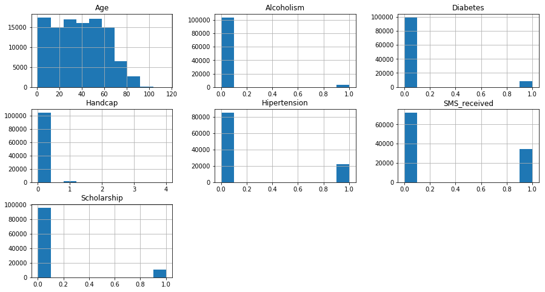

```python
# Ovarall rate.
df.hist(figsize = (15, 8))
```

### Research Question 2 ( What is the Show rate?)

```
No     85307
Yes    21680
Name: show, dtype: int64
present of show to no show
 (Attend = 80% - Absent = 20%)
```

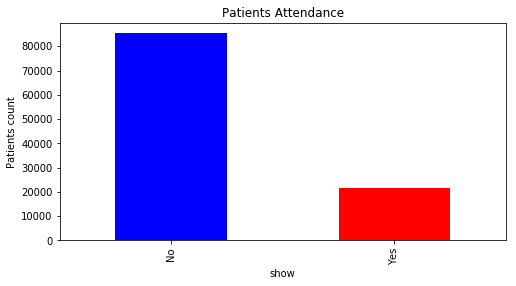

```python
# how many patients attendance.
print(df['show'].value_counts())
df['show'].value_counts().plot(kind='bar',color=['blue','red'], label=('yes','no'), figsize=(8,4))
# Set the title and label axes
plt.title('Patients Attendance')
plt.xlabel('show')
plt.ylabel('Patients count');
print('present of show to no show \n (Attend = 80% - Absent = 20%)')
```

### Research Question 3 ( Does Gender rate and Does Gender Affect of attend?)

```
F    70118
M    36869
Name: Gender, dtype: int64
Overall Gender present a Ratio (Females = 65% / Males = 35%)
```

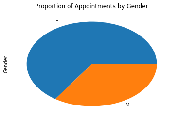

```python
# Gender Percentage.
df['Gender'].value_counts().plot(kind='pie', title='Proportion of Appointments by Gender');
print(df['Gender'].value_counts())
print ('Overall Gender present a Ratio (Females = 65% / Males = 35%)')
```

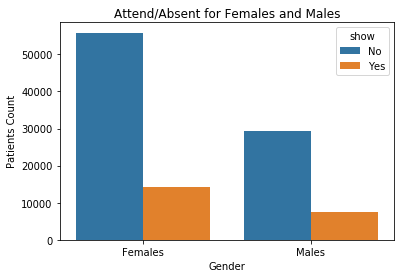

[output not shown]

```python
#dividing the patients to 2 groups according to attendence status.
Attend = df.show=='No'
Absent = df.show=='Yes'
# Create a bar chart with proper labels to Compare the 'Attendance status' According To Gender.
ax = sns.countplot(x=df.Gender, hue=df.show, data=df)
ax.set_title('Attend/Absent for Females and Males')
ax.set_xticklabels(['Females', 'Males'])
plt.ylabel('Patients Count')
plt.show()
print(df[Attend]['Gender'].value_counts())
print(df[Absent]['Gender'].value_counts())
print('The Greater percentage of women attending than man is  \n (approzimately 65% to 35%)')
```